# Notes O

Mapping in R

[figure not shown]

### Before we get started, some context:

- `R` is *fantastic* for spacial analysis (not covered in this class… look for classes related to spacial statistics)
- `R` is *great* for interactive data visualization (via `leaflet` or `shiny`… more on this on Thursday)
- `R` is *okay* at spacial data visualization (creating maps).
  - There are many different packages in `R` for creating maps. I’ve found that different packages perform best for different maps. We will talk about a few different ones today.
  - If you have a highly map-centric project, there is nothing wrong with working in ArcGIS or QGIS if you find the mapping tools in R insufficient. There are many recent improvements with new packages (like `sf`, `rgdal` and `rgeos`) which profiles much of the functionality of GIS packages! Exciting! (not very beginner friendly - requires familiarity with GIS concepts)

# Using the `maps` package

Perhaps the simplest approach to drawing maps is to use `geom_polygon()` to draw boundaries for different regions.

The `maps` package contains several built in maps: world (for all countries in the world), france, italy, nz, usa, state (usa state boundaries), and county (usa counties). The maps package isn’t particularly accurate or up-to-date, but it’s built into R so it’s an easy place to start.

To reference each map you use `map_data("mapname")`.

```r
#LOAD PACKAGES
library(tidyverse)
library(maps)

#LOAD DATA
world_map <- map_data("world")
```

# Let look at the structure of our data and some of our variables

```r
str(world_map)
```

```
'data.frame':   99338 obs. of  6 variables:
 $ long     : num  -69.9 -69.9 -69.9 -70 -70.1 ...
 $ lat      : num  12.5 12.4 12.4 12.5 12.5 ...
 $ group    : num  1 1 1 1 1 1 1 1 1 1 ...
 $ order    : int  1 2 3 4 5 6 7 8 9 10 ...
 $ region   : chr  "Aruba" "Aruba" "Aruba" "Aruba" ...
 $ subregion: chr  NA NA NA NA ...
```

- long = longitude
- lat = latitude
- group = a numeric identifier, to trace map polygons. dictates which adjacent coordinates belong together
- order = sequence in which the groups should be connected

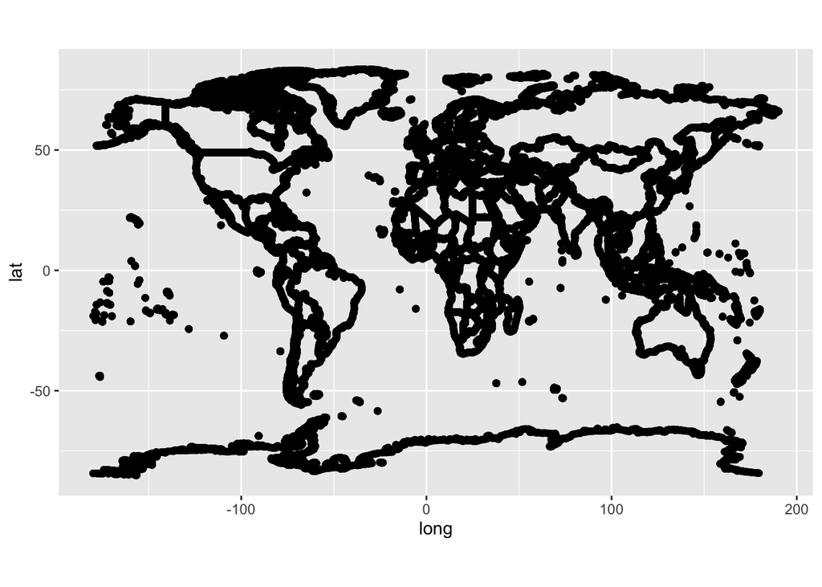

```r
# World Map
ggplot(world_map, aes(x = long, y = lat))+
  geom_point( color = "black")+
  coord_fixed(1.3)
```

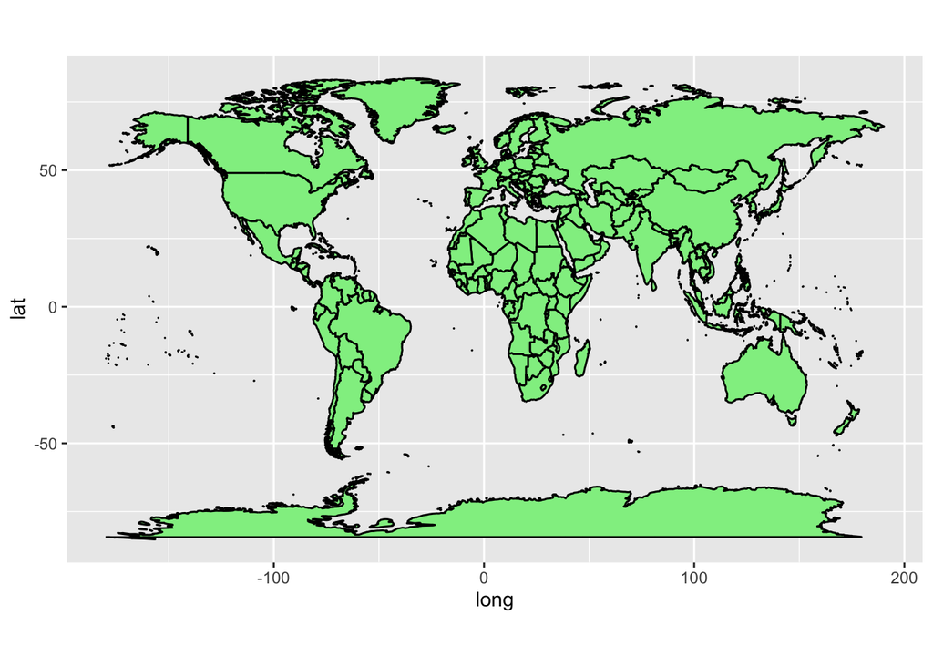

```r
# Connecting our points and creating polygons
ggplot(world_map, aes(x = long, y = lat, group = group))+
  geom_polygon(fill = "lightgreen", color = "black")+
 coord_fixed(1.3)
```

## What about subsetting the data?

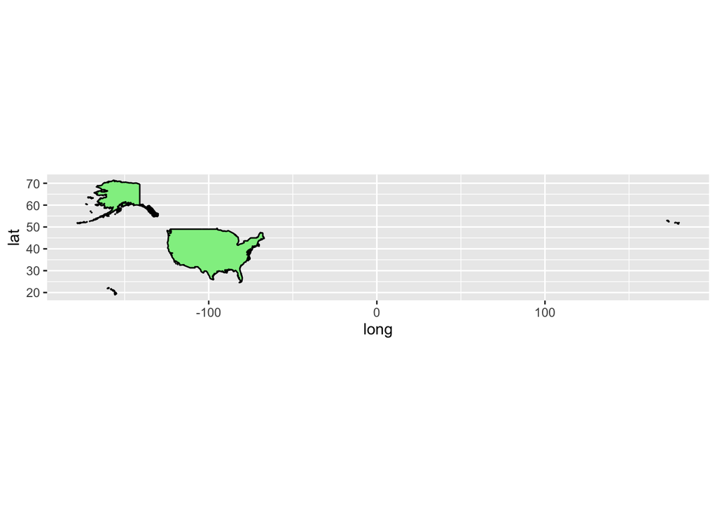

```r
#Subset to get Italy


#Subset to get USA
 usa<-world_map |>
   filter(region == "USA")

 ggplot(usa, aes(x = long, y = lat, group = group))+
   geom_polygon(fill = "lightgreen", color = "black")+
  coord_fixed(1.3)
```

```r
# ASPECT RATIO NOT MAINTAINED
```

```r
# ASPECT RATIO MAINTAINED
```

## USA with states

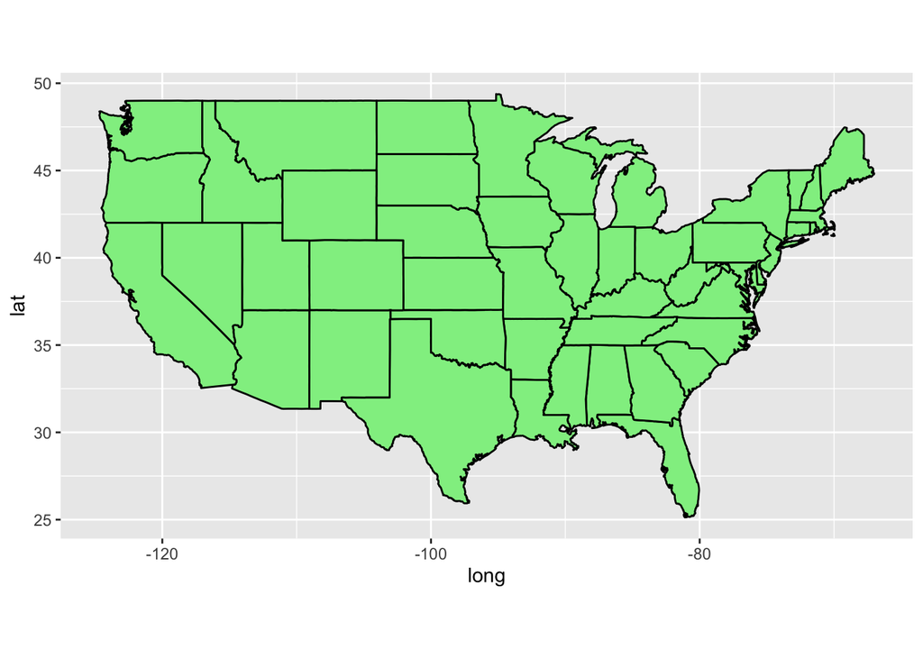

```r
#Load Data from maps
usa_states <- map_data("state")

#Plot of USA with state borders

ggplot(usa_states, aes(x = long, y = lat, group = group))+
  geom_polygon(fill = "lightgreen", color = "black")+
 coord_fixed(1.3)
```

## There are other package that designed to plot specific places

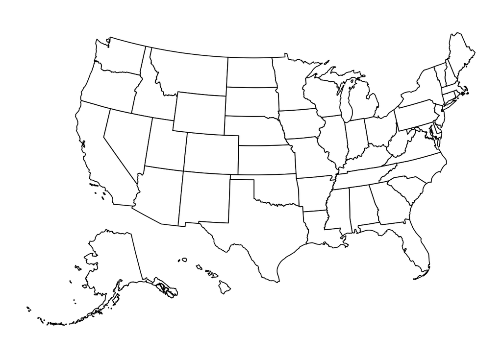

```r
library(usmap)

data<-us_map()
plot_usmap()
```

```r
#LOAD PACKAGES
library(tidyverse)
library(leaflet)
```

# Interactive maps using `leaflet`

[`leaflet` is an open-source JavaScript library that is used to create dynamic online maps.](https://bookdown.org/nicohahn/making_maps_with_r5/docs/leaflet.html) The identically named R package makes it possible to create these kinds of maps in R as well.

```r
leaflet() %>%
  addTiles() %>%
  setView(lng = -70.61, lat = 42.99, zoom = 5)
```

[interactive chart not shown]

```r
# Load spatial data with intertidal logger locations
# logger_info <- read.csv(file = "data/intertidal_temp_loggers.csv")
```

## Adding points

```r
# leaflet() |>
#   addTiles() |>
#   setView(lng = -70.61, lat = 42.99, zoom = 15) |>
#   addCircleMarkers(data=logger_info, lng = ~longitude, lat = ~latitude,
#              popup = ~logger, color="orange", opacity=1, weight =2, radius=5, fill = TRUE, fillOpacity=0.8)
```

## Different backgrounds

```r
# Use addProviderTiles(providers$Esri.WorldImagery)
# addProviderTiles(providers$Esri.WorldGrayCanvas)
```

## Saving the map

You can take a screenshot of your viewer pane or download a separate pages to same the map.

```r
# my_intertidal_map<-leaflet() |>
#   addTiles() |>
#   setView(lng = -70.61, lat = 42.99, zoom = 15) |>
#   addCircleMarkers(data=logger_info, lng = ~longitude, lat = ~latitude,
#              popup = ~logger, color="orange", opacity=1, weight =2, radius=5, fill = TRUE, fillOpacity=0.8)
# my_intertidal_map
#
# library(mapview)
# library(webshot)
# # webshot::install_phantomjs()
# mapshot(my_intertidal_map, file = "intertidal_map.png")
```

## Making maps with sf()

This is the most robust method of spatial analysis and becoming the primary package used.

- “sf” stands for simple features
- sf represents geographic vector data (e.g., points, lines, polygons, multipolygon)
- each row is a geographic feature with a special “geometry” column
- because sf spatial data lives in dataframes you can use familiar tools such as those in the tidyverse package
- can handle different coordinate reference systems
- you can read and write shapefiles
- bridges a gap between GIS and data science workflows

# Loading my site data and converting it to sf()

```r
# library(sf)
#
# my_points<-read_csv(file = "data/sites.csv")
#
# my_points<-my_points |>
#   dplyr::rename('latitude' = 'lat',
#                 'longitude' = 'lon')
# my_points<-my_points |>
#   filter(!site == "Portsmouth")

# Looking at my data structure
# my_points
# class(my_points) # my data is stored as a data.frame
#
# my_points<-st_as_sf(my_points, coords = c("longitude", "latitude"), crs = 4326)
# # st_as_sf() - converts spatial objects into sf objects
# # crs  - coordinate reference system, 4326 is one of the most commonly used and allows us to plot lat and lon
#
# my_points
# # Simple features collection
# # 5 features
# # 3 fields
```

## Ploting a map of Appledore Island

- We will start my importing a shapefile
- A shapefile (.shp) is a common file format for storing geospatial vector data
- Stores vector geometry (i.e., point, line, polygon) + attributes about that data

```r
# I downloaded a shapefile from here:
# https://www.fisheries.noaa.gov/inport/item/61710

# SML Maps -------------------------------------------------
#shoals <-read_sf("data/N40W075.shp") # I loaded my shape file

# Let's look at the data


# Trying to figure out what I can filter by to get close to only getting shoals
# shoals <-shoals |>
#   filter(NOAA_Regio == "North Atlantic") |>
#   filter(FIPS_ALPHA %in% c("ME", "NH"))

# Setting this data to crs 4326, so that it is the same as my points
# shoals <- st_transform(shoals, crs = st_crs(4326))
#
# # Okay, let's map!
# line_map<-ggplot(shoals)+
#   geom_sf(col = "lightblue")
# line_map

# Is this what we want?
```

## Changing the bounds of our map

```r
# shoals_only<-st_bbox(c(xmin = -70.633048, ymin = 42.984212,
#                        xmax = -70.607067, ymax = 42.994329), crs = st_crs(4326))
# where are changing the bound of our data, by specifying where we want "zoom" in

# shoals_sub<-st_crop(shoals, shoals_only) # crops our object to the rectangle we defined above
#
# line_map_sub<-ggplot(shoals_sub)+
#   geom_sf()
# line_map_sub

# Converting lines into polygons
# shoals_polygon<-st_polygonize(st_union(shoals_sub))
#
# # Now let's plot!
# ggplot(shoals_polygon)+
#   geom_sf(fill = "lightblue", col = "blue")

# My map + my points
# my_shoals_map<- ggplot()+
#   geom_sf(data = shoals_polygon, fill = "lightblue", col = "blue")+
#   geom_sf(data = my_points, aes(color = day))+
#   theme_bw()
# my_shoals_map

# Making it interactive
#ggplotly(my_shoals_map)


# What if I want to color my points based on different groups
# my_points$day<-as.factor(my_points$day)
#
# my_shoals_map <- ggplot()+
#   geom_sf(data = shoals_polygon, fill = "lightblue", col = "navyblue")+
#   geom_sf(data = my_points, aes(color = day, shape = day), size = 3 )+
#   geom_sf_text(data = my_points, aes(label = site),
#                       nudge_y = c(0, -0.001, -0.001, 0, 0),
#                       nudge_x = c(-0.009, 0, 0, 0.007, 0.007))+
#   labs(x = "Longitude", y = "Latitude")+
#   theme_bw()
# my_shoals_map

#ggsave(my_shoals_map, filename ="my_shoals_map.tiff")


# What if I want to color my points based on how many people were there

# my_shoals_map <- ggplot()+
#   geom_sf(data = shoals_polygon, fill = "lightgrey", col = "black")+
#   geom_sf(data = my_points, aes(color = people), size = 3 )+
#   geom_sf_text(data = my_points, aes(label = site),
#                nudge_y = c(0, -0.001, -0.001, 0, 0),
#                nudge_x = c(-0.009, 0, 0, 0.007, 0.007))+
#   labs(x = "Longitude", y = "Latitude")+
#   theme_bw()
# my_shoals_map
#
# ggsave(my_shoals_map, filename ="my_shoals_map_people.tiff")
```